# Data Visualization Project - Flight Data Exploration

## by Priyanka Krishnan

## Investigation Overview

> The goal of the project is to investigate and visualize the flight dataset to understand the factors causing flight delays along with carrier performance with respect to cancellations and delays.

## Dataset Overview

> The dataset is from the Bureau of Transportation Statistics and can be downloaded directly from https://community.amstat.org/jointscsg-section/dataexpo/dataexpo2009.

> The downloaded files were in zip format ('bz2'). This dataset consists of flight related details like month, day of week, carriers, arrival & departure delays, and reasons for delays. For the purpose of this project I have used data from years 2006-2008 (last three years in the dataset).

## What are the cancellation reasons and how are they distributed (count)?

> Carrier and Weather related cancellations are most common.

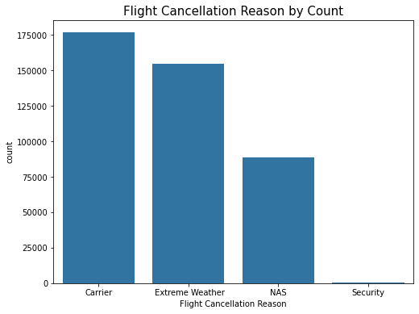

```
A    176764
B    154753
C     88392
D       208
Name: CancellationCode, dtype: int64
```

## What is the distribution of delay in flight arrival?

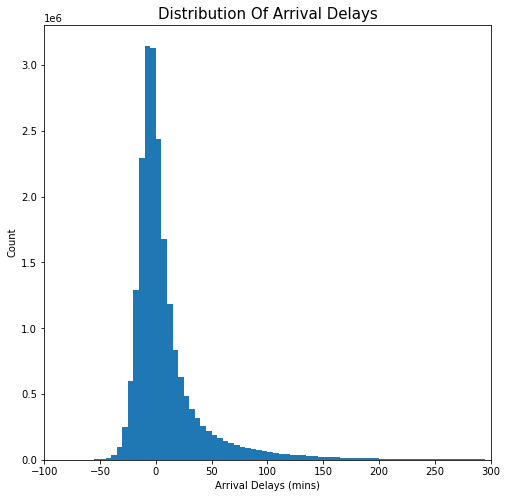

## Which aircraft carrier has most cancellations?

> 5 aircraft carriers which performed worst in terms of cancellation are:
> 1. MQ - Envoy Air Inc.,
> 2. AA - American Airlines Inc.,
> 3. OO - SkyWest Airlines,
> 4. UA - United Airlines, Inc. and ,
> 5. WN - Southwest Airlines Co.

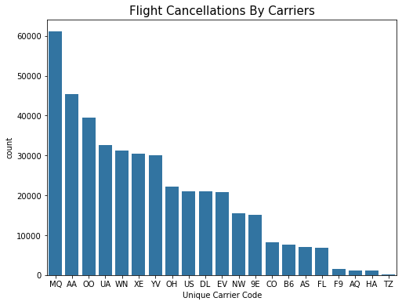

## Which aircraft carrier has the highest delays (in minutes) at Arrival? Did the same carriers perform worst at this too?

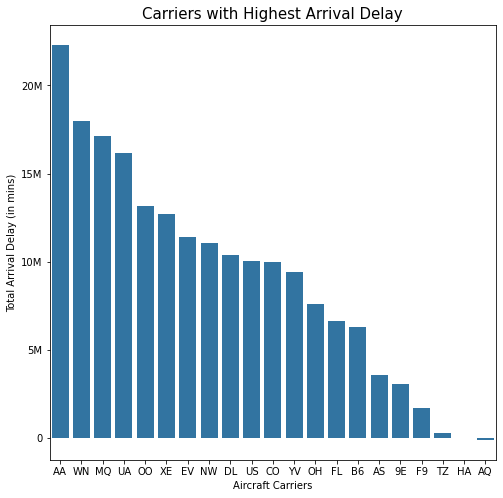

## Which aircraft carrier has the highest delays (in minutes) at Departure? Did the same carriers perform worst at this too?

> Just like arrival delays, the same set of 5 aircraft carriers also performed worst in departure delays as well (order is little differnt).
> 1. WN - Southwest Airlines Co.
> 2. AA - American Airlines Inc.,
> 3. UA - United Airlines, Inc.,
> 4. MQ - Envoy Air Inc.,
> 5. OO - SkyWest Airlines,

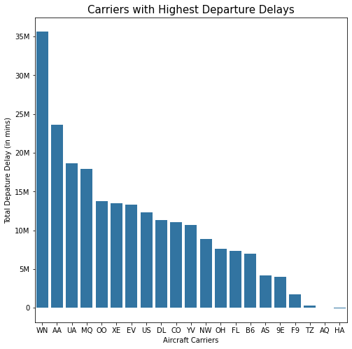

## Which aircraft carrier has most cancellations under each cancellation category?

> UA (United Airlines Inc) has the highest cancellation due to code 'A' which stands for Carriers

> MQ (Envoy Air Inc) has the highest cancellation due to code 'B' and 'C' which stands for Extreme Weather and NAS respectively

> XE (Delux Public Charter LLC dba JSX Air) has the highest cancellation due to code 'D' which stands for Security

> Note: The Cancellation Code A (Carrier) and B (Extreme Weather) are the most prominent ones; D (Security) attributes to the least number of cancellations.

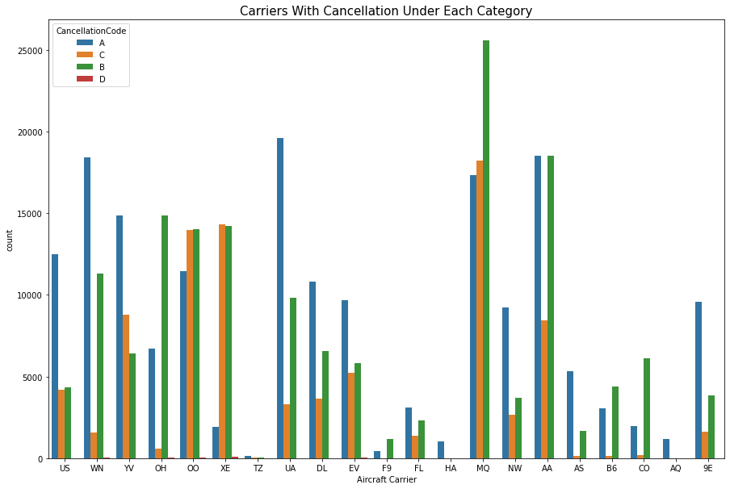

## How did each carrier (in proportion) perform in terms of arrival delays?

> TZ (ATA Airlines d/b/a ATA) has the worst performance followed by NW (Northwest Airlines Inc). The best performance is for HA (Hawaiian Airlines Inc).

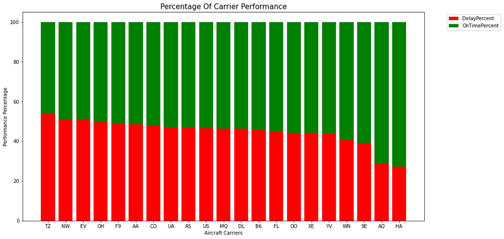

## What were the major causes of delay across months for these years?

> Both weather and late aircraft related delays contribute most to overall delays as compared to others.

> Security is the least probable cause of delay.

> Note: The average arrival delay is between 0 to 50 minutes

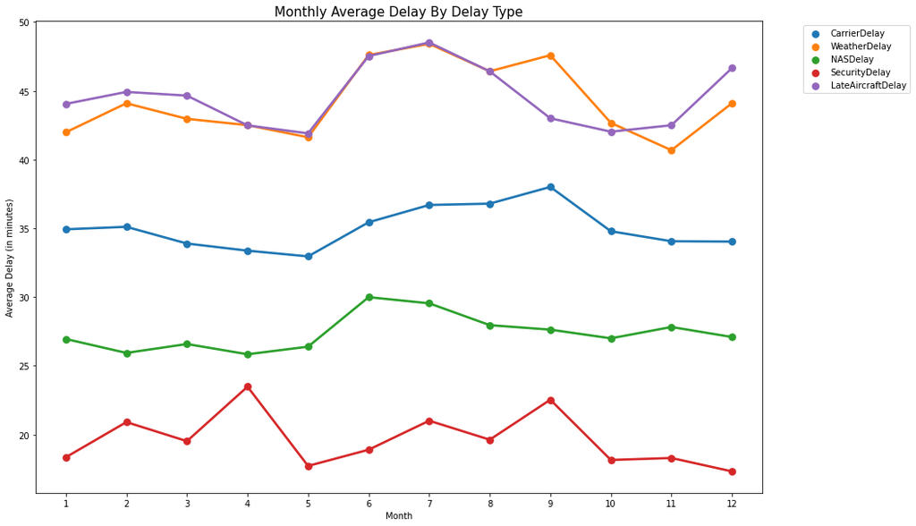

## Conclusion:

> Cancellations are mostly due to Carrier and Weather related reasons.

> Top 5 worst performing aircraft carriers in terms of cancellations and delays are: MQ - Envoy Air Inc., AA - American Airlines Inc., OO - SkyWest Airlines, UA - United Airlines, Inc. and , WN - Southwest Airlines Co.

> UA (United Airlines Inc) has the highest cancellation due to 'Carriers'. MQ (Envoy Air Inc) has the highest cancellation due to 'Extreme Weather' and 'National Aviation System' respectively. XE (Delux Public Charter LLC dba JSX Air) has the highest cancellation due to 'Security' reasons.

> TZ (ATA Airlines d/b/a ATA) and NW (Northwest Airlines Inc) had the most percentage of flights delayed in years 2006 to 2008. HA (Hawaiian Airlines Inc) has the least percentage of flights delayed in years 2006 to 2008.

> Weather, Late Aircraft and Carrier related delays were more significant than the other delays namely NAS and Security.